# Multilevel Mixed Model Creation

Rebecca Ioffe, Isabelle Phraner

2023-11-20

```r
knitr::opts_chunk$set(echo = TRUE)
```

## Library

[output not shown]

# Data Cleaning

```r
acad_perf <- read.csv("/Users/rioffe/Desktop/Statistics/Stat 414/acad_perf.csv",header=TRUE)
#head(acad_perf, 10)
```

```r
acad_perf1 <- acad_perf %>%
      mutate(Semester = if_else(Semester == "F", "First", "Second")) %>%
        mutate(gender = if_else(gender == "M", "Male", "Female"))
```

```r
acad_perf1 <- acad_perf1 %>%
   mutate(result = ifelse(Class == "M", 1,
                          ifelse(Class == "H", 1,
                          ifelse(Class == "L", 0, 0))))
```

```r
summary_hands <- acad_perf1 %>%
   group_by(PlaceofBirth) %>%
      summarise(avg_hands = round(mean(raisedhands), 2),
                sd_hands = sd(raisedhands),
                n = n())

#head(summary_hands,5)


acad_perf1 <- acad_perf1 %>%
      group_by(PlaceofBirth) %>%
      mutate(avg_hands = round(mean(raisedhands),2))

#head(acad_perf1,5)
```

```r
acad_perf1 <- acad_perf1 %>%
  mutate(grouping = paste(GradeID,SectionID, sep = "" ))
```

# Initial Model Exploration

```r
library(ggeffects)

model0 <- lm(result ~ raisedhands, data = acad_perf1)

model1 <- glmer(result ~ raisedhands + (1|grouping), family = "binomial", data = acad_perf1)
```

```
## boundary (singular) fit: see help('isSingular')
```

```r
model1b <- glmer(result ~ 1 + (1|grouping), family = "binomial", data = acad_perf1)

model1c <- glmer(result ~ 1 + (1|grouping), family = "binomial", data = acad_perf1)

model2 <- glmer(result ~ raisedhands + Semester + (1|grouping), family = "binomial", data = acad_perf1)
```

```
## boundary (singular) fit: see help('isSingular')
```

```r
model3 <- glmer(result ~ raisedhands + GradeID + (1|grouping), family = "binomial", data = acad_perf1)
```

```
## boundary (singular) fit: see help('isSingular')
```

```r
model4 <- glmer(result ~ raisedhands  + GradeID + (1|grouping), family = "binomial", data = acad_perf1)
```

```
## boundary (singular) fit: see help('isSingular')
```

```r
model5 <- glmer(result ~ raisedhands  + GradeID + ParentschoolSatisfaction + Topic + StudentAbsenceDays + (1|grouping), family = "binomial", data = acad_perf1)
```

```
## boundary (singular) fit: see help('isSingular')
```

```r
model6 <- glmer(result ~ raisedhands + (1|grouping), family = "binomial", data = acad_perf1)
```

```
## boundary (singular) fit: see help('isSingular')
```

```r
model7 <- glmer(result ~ raisedhands  + GradeID + ParentschoolSatisfaction + StudentAbsenceDays + (1|grouping), family = "binomial", data = acad_perf1)
```

```
## boundary (singular) fit: see help('isSingular')
```

#1. Exploring Variability

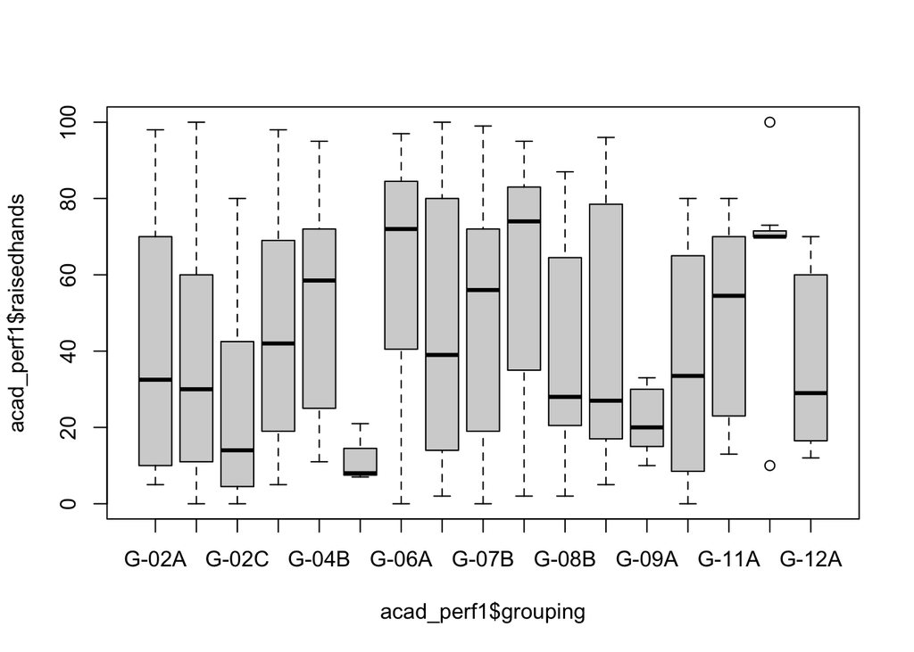

```r
#Plot of variability in response variable across the level 2 units

#level 2 units: Grouping Variable

library(ggeffects)

boxplot(acad_perf1$raisedhands ~ acad_perf1$grouping)
```

```
## Data were 'prettified'. Consider using `terms="raisedhands [all]"` to
##   get smooth plots.
```

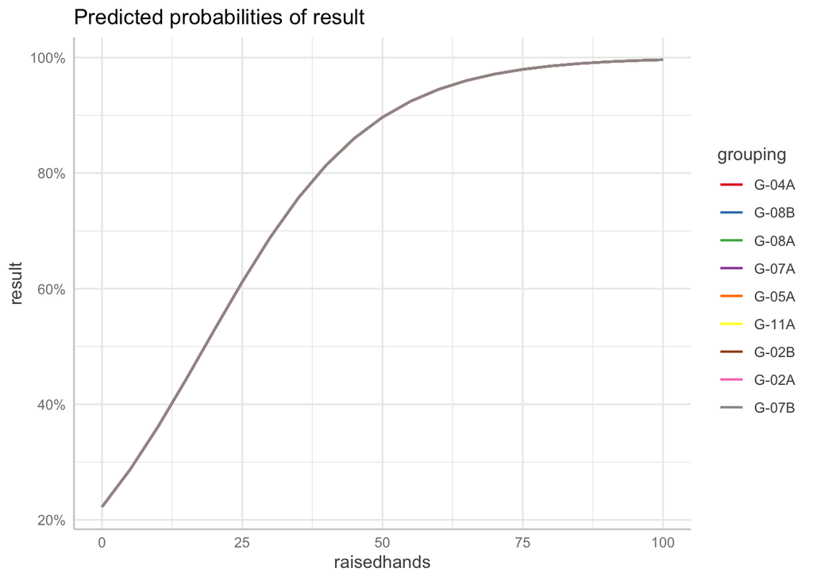

```r
plot(ggeffects::ggpredict(model1, terms=c("raisedhands", "grouping [sample = 9]"), type = "re"), ci = FALSE)
```

```r
#Fit an Chi-SQ using ols for response variable and the level-2 grouping variable to test for signifigance of grouping variable.

#choosing between gradeID and semester

chisq.test(acad_perf1$result, acad_perf1$grouping)
```

```
##
##  Pearson's Chi-squared test
##
## data:  acad_perf1$result and acad_perf1$grouping
## X-squared = 29.409, df = 16, p-value = 0.02132
```

The group effect seems to be statistically significant. We fit an ANOVA for the grouping variable - combining grade level and section to test its significance. To begin exploring variation in one of our explanatory variables, raisedhands, we aggregated two separate level two variables called grade and section into a single level two variable, “grouping” using the paste function in R. The box plot of raised hands by grouping indicates considerable variation in the distribution of the raisedhands variable across the different groups.

We also examined the predicted probabilities of ‘result’ by grade grouping. The predicted probabilities completely converged.

As raisedhands increases, the probability of the positive result also increases for all groups, but this effect seems consistent across the groups since the lines are parallel. This implies that the effect of raisedhands on the result does not differ by group in the model.

We had a chisq value of 29.409 , with a p-value of 0.02132, so we can conclude that grouping effect is statistically significant.

#2. Fitting the “intercepts only” model.

```r
intercepts_model <- glmer(result ~ 1 + (1|grouping), family = "binomial", data = acad_perf1)
summary(intercepts_model)
```

```
## Generalized linear mixed model fit by maximum likelihood (Laplace
##   Approximation) [glmerMod]
##  Family: binomial  ( logit )
## Formula: result ~ 1 + (1 | grouping)
##    Data: acad_perf1
##
##      AIC      BIC   logLik deviance df.resid
##    556.4    564.8   -276.2    552.4      478
##
## Scaled residuals:
##     Min      1Q  Median      3Q     Max
## -2.1146 -1.4565  0.5330  0.6203  0.6866
##
## Random effects:
##  Groups   Name        Variance Std.Dev.
##  grouping (Intercept) 0.1108   0.3328
## Number of obs: 480, groups:  grouping, 17
##
## Fixed effects:
##             Estimate Std. Error z value Pr(>|z|)
## (Intercept)   1.0715     0.1507   7.108 1.18e-12 ***
## ---
## Signif. codes:  0 '***' 0.001 '**' 0.01 '*' 0.05 '.' 0.1 ' ' 1
```

```r
performance(intercepts_model)
```

| AIC | AICc | BIC | R2_conditional | R2_marginal | ICC | RMSE | Sigma | Log_loss | Score_log | Score_spherical |
| --- | --- | --- | --- | --- | --- | --- | --- | --- | --- | --- |
| 556.4431 | 556.4682 | 564.7907 | 0.03257078 | 0 | 0.03257078 | 0.4347536 | 1 | 0.5628702 | -470.6839 | Inf |

ICC: 0.0326

The ICC is 0.0326, so 3.26% of the total variability in the the result can be attributed to differences between the groups identified by the grouping variable. The relatively small ICC suggests that while there is some variability in the results between groups, most of the variability is within the groups or due to other factors not included in the model - or is explained by our raised hands variable. Therefore - it does not seem quite substantial - however, the grouping variable was significant.

Fixed Effects Estimate of Intercept: 1.0715

The estimated fixed effect for the intercept is 1.0715. In the context of a logistic regression model, this parameter represents the log odds of the outcome variable when all predictors are at their reference levels - or, at the average log odds of passing/failing a class across the grouping variable with grade level and section.

Variance of Random Effects of Grouping Variable: 0.1108

The variance of the random intercepts is 0.1108 - this means that the variability of the log odds of the result in the class being success between the different levels of the grouping variable is about 0.1108.

#3. Adding 1-3 Level 1 variables.

```r
model8 <- glmer(result ~ raisedhands + ParentschoolSatisfaction + StudentAbsenceDays + (1|grouping), family = "binomial", data = acad_perf1)
```

```
## boundary (singular) fit: see help('isSingular')
```

```r
model8b <- glmer(result ~  ParentschoolSatisfaction + StudentAbsenceDays + (1|grouping), family = "binomial", data = acad_perf1)


summary(model8)
```

```
## Generalized linear mixed model fit by maximum likelihood (Laplace
##   Approximation) [glmerMod]
##  Family: binomial  ( logit )
## Formula:
## result ~ raisedhands + ParentschoolSatisfaction + StudentAbsenceDays +
##     (1 | grouping)
##    Data: acad_perf1
##
##      AIC      BIC   logLik deviance df.resid
##    244.7    265.6   -117.3    234.7      475
##
## Scaled residuals:
##      Min       1Q   Median       3Q      Max
## -20.5744  -0.2483   0.0486   0.2202   3.4385
##
## Random effects:
##  Groups   Name        Variance Std.Dev.
##  grouping (Intercept) 0        0
## Number of obs: 480, groups:  grouping, 17
##
## Fixed effects:
##                               Estimate Std. Error z value Pr(>|z|)
## (Intercept)                  -2.913097   0.368110  -7.914 2.50e-15 ***
## raisedhands                   0.063293   0.008789   7.201 5.98e-13 ***
## ParentschoolSatisfactionGood  1.258767   0.341165   3.690 0.000225 ***
## StudentAbsenceDaysUnder-7     3.271892   0.395056   8.282  < 2e-16 ***
## ---
## Signif. codes:  0 '***' 0.001 '**' 0.01 '*' 0.05 '.' 0.1 ' ' 1
##
## Correlation of Fixed Effects:
##             (Intr) rsdhnd PrntSG
## raisedhands -0.715
## PrntschlStG -0.559  0.138
## StdntAbDU-7 -0.453  0.178  0.176
## optimizer (Nelder_Mead) convergence code: 0 (OK)
## boundary (singular) fit: see help('isSingular')
```

```r
summary(model8b)
```

```
## Generalized linear mixed model fit by maximum likelihood (Laplace
##   Approximation) [glmerMod]
##  Family: binomial  ( logit )
## Formula: result ~ ParentschoolSatisfaction + StudentAbsenceDays + (1 |
##     grouping)
##    Data: acad_perf1
##
##      AIC      BIC   logLik deviance df.resid
##    327.1    343.8   -159.6    319.1      476
##
## Scaled residuals:
##     Min      1Q  Median      3Q     Max
## -8.3440 -0.4365  0.1353  0.2859  2.2910
##
## Random effects:
##  Groups   Name        Variance Std.Dev.
##  grouping (Intercept) 0.2608   0.5107
## Number of obs: 480, groups:  grouping, 17
##
## Fixed effects:
##                              Estimate Std. Error z value Pr(>|z|)
## (Intercept)                   -1.1686     0.2746  -4.256 2.08e-05 ***
## ParentschoolSatisfactionGood   1.5311     0.3005   5.096 3.48e-07 ***
## StudentAbsenceDaysUnder-7      3.7322     0.3708  10.064  < 2e-16 ***
## ---
## Signif. codes:  0 '***' 0.001 '**' 0.01 '*' 0.05 '.' 0.1 ' ' 1
##
## Correlation of Fixed Effects:
##             (Intr) PrntSG
## PrntschlStG -0.566
## StdntAbDU-7 -0.374  0.202
```

```r
anova(model8, intercepts_model)
```

|  | npar | AIC | BIC | logLik | deviance | Chisq | Df | Pr(>Chisq) |
| --- | --- | --- | --- | --- | --- | --- | --- | --- |
| intercepts_model | 2 | 556.4431 | 564.7907 | -276.2215 | 552.4431 | NA | NA | NA |
| model8 | 5 | 244.6901 | 265.5590 | -117.3450 | 234.6901 | 317.753 | 3 | 1.429414e-68 |

```r
#anova(model8b, intercepts_model)
#anova(model8, model8b)
```

Anova comparison of model8b without raisedhands to intercepts only model:

P-value: 2.2e^-16 df = 2

AIC BIC 327.13 343.83

Anova comparison of model with raisedhands to intercepts only model:

P-value: 2.2e^-16 df = 3

AIC BIC 244.69 265.56

Anova comparison comparing model8 and model8b:

Where df is the difference in the number of terms between each model. Where the p-value is found from the Chi-Squared p-value in ANOVA comparison output.

From the model summary output, we can see that all of the added level 1 variables in the model: parent school satisfaction, measured as a categorical good or bad, and Student absence days, categorical under-7 or over-7 are significant in explaining variation in student result in the class. Therefore, we decided to keep these variables in the model to help explain some of the level 1 variation in student pass/fail result as there is not a lot of level 2 variation in the grouping variable. With the addition of these level one variables into the model, the level 2 variation increased from 0.1108 in the intercepts-only model to 0.2608 in the model containing our level 1 variables. This would mean that adding parent school satisfaction and student absences into the model would explain some level 1 variation in student academic result, however, these variables would provide information that would contribute to group-to-group variation in average result - providing more higher than average or lower than average estimates.

In the anova output comparing model8 and model8b, we can see that the model with raised hands has much lower AIC and BIC values. Therefore, we know that adding raised hands back into the model will increase model performance in predicting class result significantly.

Proportion of Variation Explained:

Model 8:

random effects grouping variance: 0 intercept standard error: 0.368110

Model 8b:

random effects grouping variance: 0.2608 intercept standard error: 0.2746

Intercepts-only model:

random effects grouping variance: 0.1108 intercept standard error: 0.1507

Adding raised hands back into the model causes the level 2 variation in pass/fail results to be essentially 0. This means that raised hands accounts for most of the variation in pass/fail results - therefore - level 2 variation in Class/section grouping is essentially 0.

#4.Adding 1-3 Level 2 variables.

```r
model9 <- glmer(result ~ StageID + Semester + ParentschoolSatisfaction + StudentAbsenceDays + (1|grouping), family = "binomial", data = acad_perf1)


model9b <- glmer(result ~ Semester + ParentschoolSatisfaction + StudentAbsenceDays + (1|grouping), family = "binomial", data = acad_perf1)

model9c <- glmer(result ~ raisedhands + ParentschoolSatisfaction + StudentAbsenceDays + (1|grouping), family = "binomial", data = acad_perf1)
```

```
## boundary (singular) fit: see help('isSingular')
```

```r
summary(model9)
```

```
## Generalized linear mixed model fit by maximum likelihood (Laplace
##   Approximation) [glmerMod]
##  Family: binomial  ( logit )
## Formula:
## result ~ StageID + Semester + ParentschoolSatisfaction + StudentAbsenceDays +
##     (1 | grouping)
##    Data: acad_perf1
##
##      AIC      BIC   logLik deviance df.resid
##    328.6    357.8   -157.3    314.6      473
##
## Scaled residuals:
##     Min      1Q  Median      3Q     Max
## -9.5491 -0.3925  0.1413  0.2485  2.5480
##
## Random effects:
##  Groups   Name        Variance Std.Dev.
##  grouping (Intercept) 0.1202   0.3468
## Number of obs: 480, groups:  grouping, 17
##
## Fixed effects:
##                              Estimate Std. Error z value Pr(>|z|)
## (Intercept)                  -1.31976    0.64620  -2.042   0.0411 *
## StageIDlowerlevel            -0.33278    0.68341  -0.487   0.6263
## StageIDMiddleSchool           0.04034    0.68240   0.059   0.9529
## SemesterSecond                0.56339    0.30223   1.864   0.0623 .
## ParentschoolSatisfactionGood  1.55692    0.30248   5.147 2.64e-07 ***
## StudentAbsenceDaysUnder-7     3.66457    0.37354   9.810  < 2e-16 ***
## ---
## Signif. codes:  0 '***' 0.001 '**' 0.01 '*' 0.05 '.' 0.1 ' ' 1
##
## Correlation of Fixed Effects:
##             (Intr) StgIDl StIDMS SmstrS PrntSG
## StgIDlwrlvl -0.853
## StgIDMddlSc -0.856  0.845
## SemestrScnd -0.141 -0.079 -0.129
## PrntschlStG -0.203 -0.077 -0.033  0.068
## StdntAbDU-7 -0.186  0.033  0.036  0.007  0.201
```

```r
#Likelihood Ratio Test to compare model performance
#compare AIC values

anova(model9,model9b)
```

|  | npar | AIC | BIC | logLik | deviance | Chisq | Df | Pr(>Chisq) |
| --- | --- | --- | --- | --- | --- | --- | --- | --- |
| model9b | 5 | 325.5018 | 346.3708 | -157.7509 | 315.5018 | NA | NA | NA |
| model9 | 7 | 328.5596 | 357.7761 | -157.2798 | 314.5596 | 0.9422043 | 2 | 0.6243138 |

```r
anova(model9, model8)
```

|  | npar | AIC | BIC | logLik | deviance | Chisq | Df | Pr(>Chisq) |
| --- | --- | --- | --- | --- | --- | --- | --- | --- |
| model8 | 5 | 244.6901 | 265.5590 | -117.3450 | 234.6901 | NA | NA | NA |
| model9 | 7 | 328.5596 | 357.7761 | -157.2798 | 314.5596 | 0 | 2 | 1 |

Proportion of Variance Explained:

Model 8b:

random effects grouping variance: 0.2608 intercept standard error: 0.2746

Model 9: grouping: 0.1202 intercept: 0.64620

Adding level 2 variables into the model explained about 53.91% of the variation in average class pass/fail result in the level 2 grouping variable. Also, these variables explained no variation in average pass/fail results in the average group. These were the comparisons without raised hands added into the model. When we add raised hands back into the model, the grouping variance again becomes 0 and the standard error of the intercept decreases as well.

#5.Adding random slopes for one Level 1 variable.

Including graph illustrating variability in the estimated random slopes

Interpreting the amount of group-to-group variation in these slopes in context.

```r
library(ggeffects)

model10 <- glmer(result ~  ParentschoolSatisfaction + StudentAbsenceDays + (Discussion|grouping), family = "binomial", data = acad_perf1)
```

```
## boundary (singular) fit: see help('isSingular')
```

```r
model10b <- glmer(result ~  raisedhands + ParentschoolSatisfaction + StudentAbsenceDays + (Discussion|grouping), family = "binomial", data = acad_perf1)
```

```
## boundary (singular) fit: see help('isSingular')
```

```r
summary(model10)
```

```
## Generalized linear mixed model fit by maximum likelihood (Laplace
##   Approximation) [glmerMod]
##  Family: binomial  ( logit )
## Formula:
## result ~ ParentschoolSatisfaction + StudentAbsenceDays + (Discussion |
##     grouping)
##    Data: acad_perf1
##
##      AIC      BIC   logLik deviance df.resid
##    321.0    346.1   -154.5    309.0      474
##
## Scaled residuals:
##     Min      1Q  Median      3Q     Max
## -6.0485 -0.3816  0.1305  0.2403  2.7944
##
## Random effects:
##  Groups   Name        Variance Std.Dev. Corr
##  grouping (Intercept) 0.352767 0.59394
##           Discussion  0.001652 0.04065  -1.00
## Number of obs: 480, groups:  grouping, 17
##
## Fixed effects:
##                              Estimate Std. Error z value Pr(>|z|)
## (Intercept)                   -1.6768     0.3704  -4.527 5.99e-06 ***
## ParentschoolSatisfactionGood   1.5580     0.3221   4.837 1.32e-06 ***
## StudentAbsenceDaysUnder-7      3.7075     0.3843   9.648  < 2e-16 ***
## ---
## Signif. codes:  0 '***' 0.001 '**' 0.01 '*' 0.05 '.' 0.1 ' ' 1
##
## Correlation of Fixed Effects:
##             (Intr) PrntSG
## PrntschlStG -0.658
## StdntAbDU-7 -0.421  0.209
## optimizer (Nelder_Mead) convergence code: 0 (OK)
## boundary (singular) fit: see help('isSingular')
```

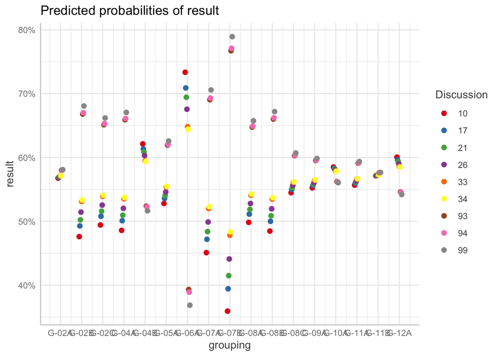

```r
plot(ggeffects::ggpredict(model10b, terms=c("grouping", "Discussion [sample = 9]"), type = "re"), ci = FALSE)
```

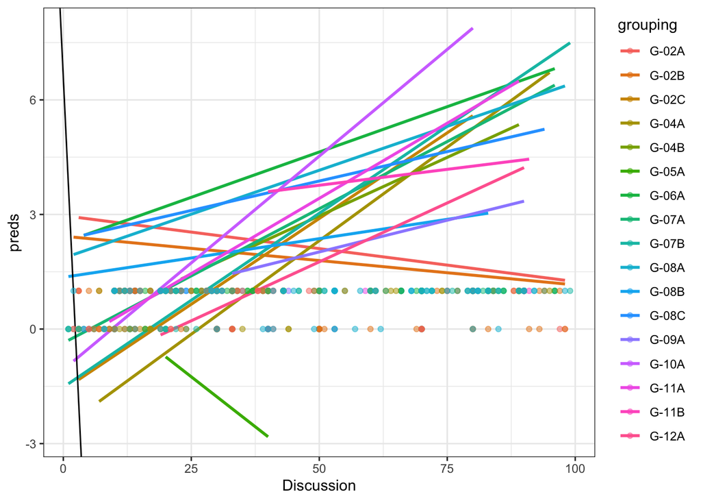

```r
preds = predict(model10b, newdata = acad_perf1)

ggplot(acad_perf1, aes(x = Discussion , y = preds , group = grouping, color = grouping )) +
geom_smooth(method = "lm", alpha = .5, se = FALSE) +
geom_abline(intercept = 6.58, slope = -2.83) +
geom_point(data = acad_perf1, aes(y = result, color= grouping), alpha = .5) +
  theme_bw()
```

```r
#comparing performance of model with and without random slopes

anova(model10, model8b)
```

|  | npar | AIC | BIC | logLik | deviance | Chisq | Df | Pr(>Chisq) |
| --- | --- | --- | --- | --- | --- | --- | --- | --- |
| model8b | 4 | 327.131 | 343.8262 | -159.5655 | 319.131 | NA | NA | NA |
| model10 | 6 | 321.012 | 346.0547 | -154.5060 | 309.012 | 10.11908 | 2 | 0.006348494 |

When adding random slopes on the level 1 variable discussion - which indicates the amount of times that students participated in class discussions - across the grouping variable, we saw that this model was significantly better then the model without random slopes on this variable. From the anova chisq p-value of 0.006 and a df of 2, adding random slopes on the discussion variable is a significant improvement compared to the model without random slopes.

The random slopes plot shows significant variability in the slopes of “discussion” across groups. There are a few negative slopes, positive slopes, and varying slope steepness across the groups.

#6.Adding cross-level interaction

```r
model11 <- glmer(result ~  ParentschoolSatisfaction + StudentAbsenceDays + (Discussion|grouping) + Discussion*Semester, family = "binomial", data = acad_perf1)
model11b <- glmer(result ~ raisedhands + ParentschoolSatisfaction + StudentAbsenceDays + (Discussion|grouping) + Discussion*Semester, family = "binomial", data = acad_perf1)
summary(model11b)
```

```
## Generalized linear mixed model fit by maximum likelihood (Laplace
##   Approximation) [glmerMod]
##  Family: binomial  ( logit )
## Formula:
## result ~ raisedhands + ParentschoolSatisfaction + StudentAbsenceDays +
##     (Discussion | grouping) + Discussion * Semester
##    Data: acad_perf1
##
##      AIC      BIC   logLik deviance df.resid
##    246.6    288.4   -113.3    226.6      470
##
## Scaled residuals:
##      Min       1Q   Median       3Q      Max
## -15.9619  -0.1825   0.0379   0.1982   4.7669
##
## Random effects:
##  Groups   Name        Variance  Std.Dev. Corr
##  grouping (Intercept) 1.186e-03 0.034441
##           Discussion  6.548e-05 0.008092 0.75
## Number of obs: 480, groups:  grouping, 17
##
## Fixed effects:
##                               Estimate Std. Error z value Pr(>|z|)
## (Intercept)                  -3.570566   0.573053  -6.231 4.64e-10 ***
## raisedhands                   0.061501   0.009541   6.446 1.15e-10 ***
## ParentschoolSatisfactionGood  1.428629   0.373318   3.827  0.00013 ***
## StudentAbsenceDaysUnder-7     3.371991   0.428149   7.876 3.39e-15 ***
## Discussion                    0.016730   0.011233   1.489  0.13637
## SemesterSecond               -0.231930   0.619441  -0.374  0.70809
## Discussion:SemesterSecond     0.013035   0.015084   0.864  0.38751
## ---
## Signif. codes:  0 '***' 0.001 '**' 0.01 '*' 0.05 '.' 0.1 ' ' 1
##
## Correlation of Fixed Effects:
##             (Intr) rsdhnd PrntSG SADU-7 Dscssn SmstrS
## raisedhands -0.426
## PrntschlStG -0.490  0.164
## StdntAbDU-7 -0.418  0.224  0.269
## Discussion  -0.669  0.000  0.149  0.126
## SemestrScnd -0.424 -0.150  0.024  0.026  0.437
## Dscssn:SmsS  0.293  0.061  0.016 -0.006 -0.444 -0.813
## optimizer (Nelder_Mead) convergence code: 0 (OK)
## Model failed to converge with max|grad| = 0.0781944 (tol = 0.002, component 1)
```

```r
anova(model11, model10)
```

|  | npar | AIC | BIC | logLik | deviance | Chisq | Df | Pr(>Chisq) |
| --- | --- | --- | --- | --- | --- | --- | --- | --- |
| model10 | 6 | 321.0120 | 346.0547 | -154.5060 | 309.0120 | NA | NA | NA |
| model11 | 9 | 310.1334 | 347.6975 | -146.0667 | 292.1334 | 16.87853 | 3 | 0.000748581 |

```r
anova(model11, model10b)
```

|  | npar | AIC | BIC | logLik | deviance | Chisq | Df | Pr(>Chisq) |
| --- | --- | --- | --- | --- | --- | --- | --- | --- |
| model10b | 7 | 247.2994 | 276.5159 | -116.6497 | 233.2994 | NA | NA | NA |
| model11 | 9 | 310.1334 | 347.6975 | -146.0667 | 292.1334 | 0 | 2 | 1 |

```r
finalmodel <- glmer(result ~ raisedhands + ParentschoolSatisfaction + StudentAbsenceDays + (Discussion|grouping) + Discussion*Semester, family = "binomial", data = acad_perf1)
```

Interpret Interaction:

The coefficient for the interaction term Discussion*Semester is 0.013035. This means that when school is in the Second Semester, the effect of semester on how many times a student participates in a discussion during class increases - keeping constant parental satisfaction, student absence and at the average discussion participation.

Checking Residual Assumptions for Logistic Regression:

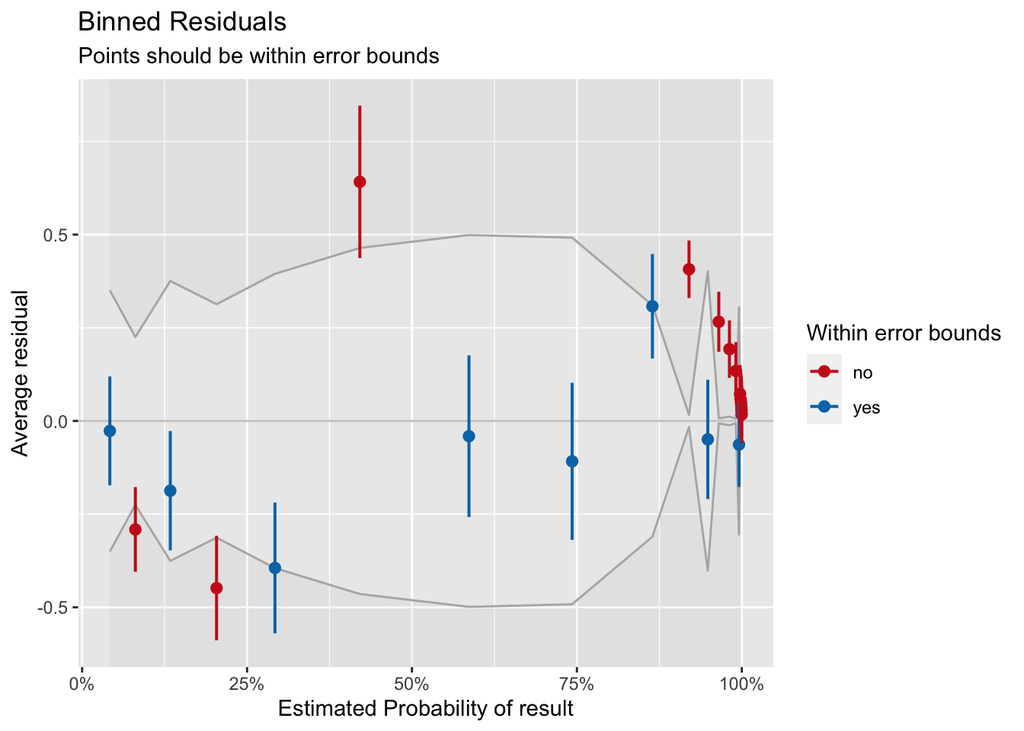

```r
performance::binned_residuals(model11b) %>% plot()
```

```r
performance::binned_residuals(model11b)
```

|  | xbar | ybar | n | x.lo | x.hi | se | CI_low | CI_high | group |
| --- | --- | --- | --- | --- | --- | --- | --- | --- | --- |
| conf_int | 0.04196949 | -0.02667217 | 21 | 0.02390431 | 0.06481886 | 0.3505447927 | -0.172684714 | 0.11934038 | yes |
| conf_int1 | 0.08069287 | -0.29115585 | 22 | 0.06612443 | 0.10666601 | 0.2250714794 | -0.404802978 | -0.17750873 | no |
| conf_int2 | 0.13361726 | -0.18723154 | 22 | 0.10909064 | 0.16259477 | 0.3754457176 | -0.347264660 | -0.02719841 | yes |
| conf_int3 | 0.20377509 | -0.44840703 | 22 | 0.16736709 | 0.23204086 | 0.3131959416 | -0.588610610 | -0.30820345 | no |
| conf_int4 | 0.29229651 | -0.39442370 | 22 | 0.23453975 | 0.35508091 | 0.3947620101 | -0.569912946 | -0.21893446 | yes |
| conf_int5 | 0.42095104 | 0.64159605 | 21 | 0.36452549 | 0.50493735 | 0.4642561980 | 0.437125188 | 0.84606690 | no |
| conf_int6 | 0.58638812 | -0.04088779 | 22 | 0.50499355 | 0.67545425 | 0.4988513534 | -0.257904479 | 0.17612890 | yes |
| conf_int7 | 0.74277227 | -0.10837931 | 22 | 0.67776327 | 0.81871706 | 0.4917765921 | -0.319101255 | 0.10234264 | yes |
| conf_int8 | 0.86446208 | 0.30771926 | 22 | 0.82109746 | 0.89833409 | 0.3105445644 | 0.167515687 | 0.44792284 | yes |
| conf_int9 | 0.91995134 | 0.40701233 | 22 | 0.89870490 | 0.94133174 | 0.0162789263 | 0.329826073 | 0.48419859 | no |

[output cut: 12 more lines]

#Other Work Done

```r
## centering the raisedhands variable

# Calculate the mean of the raisedhands variable
mean_raisedhands <- mean(acad_perf1$raisedhands)

# Create a centered variable with the name 'raisedhands_centered'
raisedhands_centered <- acad_perf1$raisedhands - mean_raisedhands

# Optionally, if we want to add it back to our dataframe:
acad_perf1$raisedhands_centered <- raisedhands_centered
```

### Boxplot of Pass/Fail Against Raised Hands

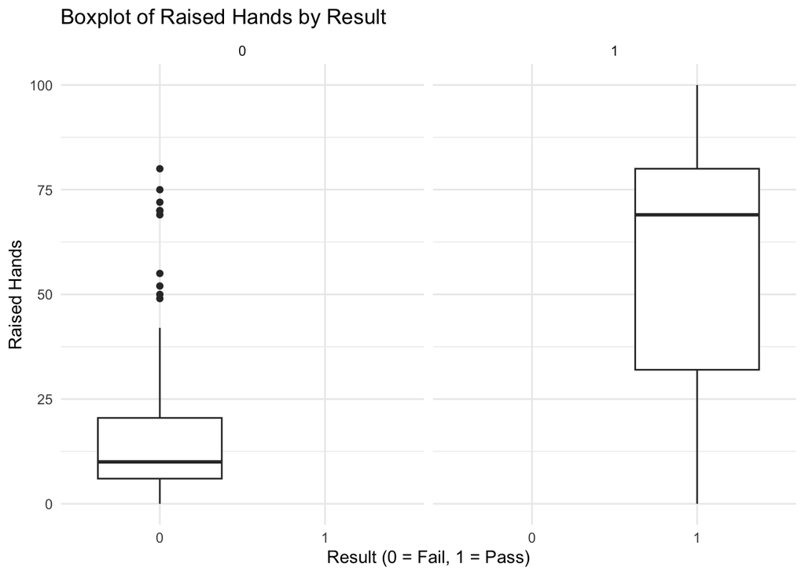

```r
library(ggplot2)
# using binary result

ggplot(acad_perf1, aes(x = as.factor(result), y = raisedhands)) +
  geom_boxplot() +
  facet_wrap(~ result) +
  labs(title = "Boxplot of Raised Hands by Result",
       x = "Result (0 = Fail, 1 = Pass)",
       y = "Raised Hands") +
  theme_minimal()
```

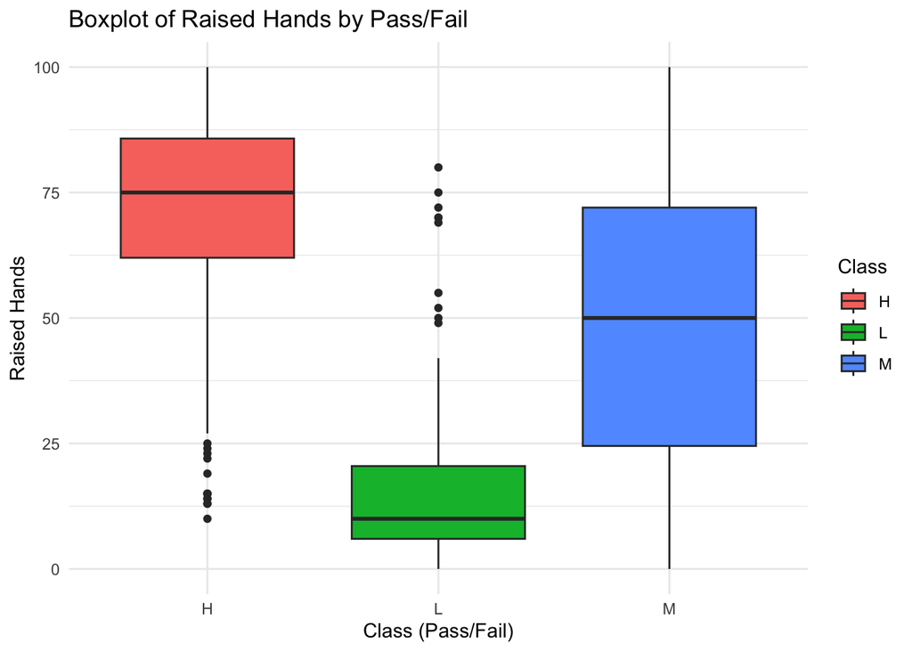

```r
# using categorical Class

ggplot(acad_perf1, aes(x = Class, y = raisedhands, fill = Class)) +
  geom_boxplot() +
  labs(title = "Boxplot of Raised Hands by Pass/Fail",
       x = "Class (Pass/Fail)",
       y = "Raised Hands") +
  theme_minimal()
```

### Histogram of Raised Hands for Pass/Fail Classes

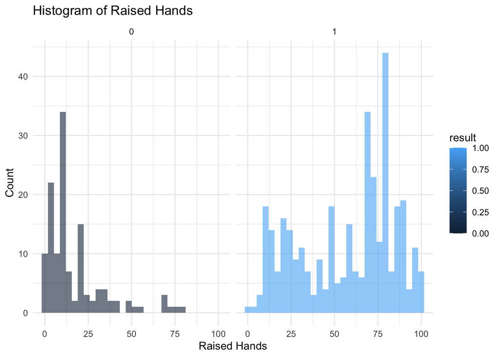

```r
ggplot(acad_perf1, aes(x = raisedhands, fill = result)) +
  geom_histogram(bins = 30, position = "identity", alpha = 0.6) +
  labs(title = "Histogram of Raised Hands",
       x = "Raised Hands",
       y = "Count") +
  facet_wrap(~ result) +
  theme_minimal()
```

##Exploration into switching explanatory and response variables

```r
#Switching Response and Explanatory Variables Exploration
modelb1 <- lmer(raisedhands ~ Topic + result + (1 | GradeID), data = acad_perf1)
#summary(model10)

# Model 11: influence of StageID and Result on raised hands
modelb2 <- lmer(raisedhands ~ StageID + result + (1 | PlaceofBirth), data = acad_perf1)
#summary(model11)

# Model 12: combined impact of Topic, Result, and Grade on raised hands
modelb3 <- lmer(raisedhands ~ Topic + result + (1 | GradeID), data = acad_perf1)
#summary(model12)
```

##Confidence Interval Calculation

```r
table <- summary(model1)$coefficients
#kbl(table)
table
```

```
##                Estimate  Std. Error   z value     Pr(>|z|)
## (Intercept) -1.25153514 0.208563234 -6.000747 1.964122e-09
## raisedhands  0.06823664 0.007028272  9.708879 2.763589e-22
```

```r
table1 <- confint.merMod(model11b, method = "Wald")
 #table1 %>%
  # kbl() %>%
   #kable_styling()

table1
```

```
##                                     2.5 %      97.5 %
## .sig01                                 NA          NA
## .sig02                                 NA          NA
## .sig03                                 NA          NA
## (Intercept)                  -4.693729248 -2.44740293
## raisedhands                   0.042802302  0.08020055
## ParentschoolSatisfactionGood  0.696940227  2.16031804
## StudentAbsenceDaysUnder-7     2.532835134  4.21114658
## Discussion                   -0.005285241  0.03874562
## SemesterSecond               -1.446012594  0.98215196
## Discussion:SemesterSecond    -0.016529614  0.04259937
```

##Exploratory Plots

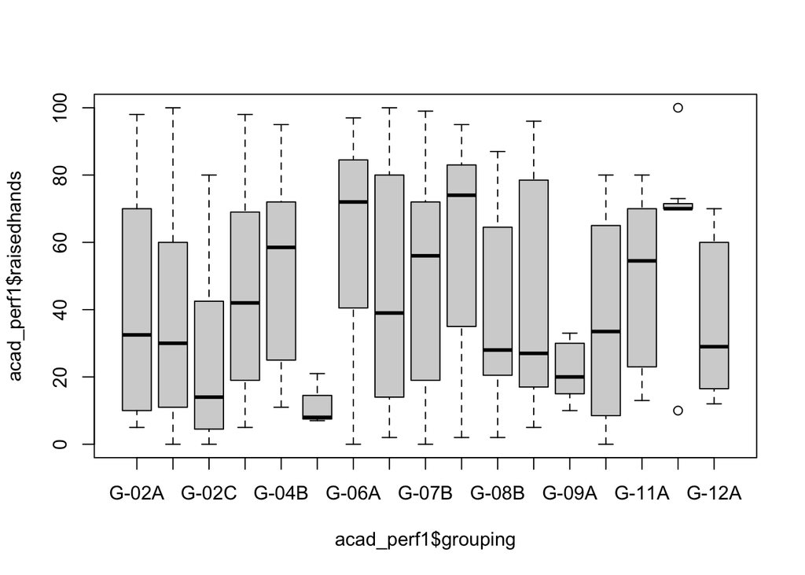

```r
boxplot(acad_perf1$raisedhands ~ acad_perf1$grouping)
```

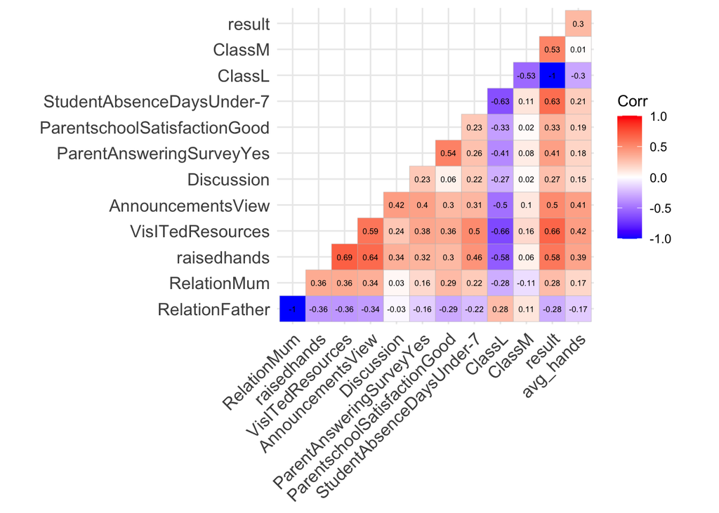

```r
#correlation matrix for data

library(ggcorrplot)
model.matrix(~0+., data = acad_perf1[9:19]) %>%
  cor(use = "pairwise.complete.obs") %>%
  ggcorrplot(show.diag = FALSE, type = "lower", lab = TRUE, lab_size = 2)
```

##Exporting Data File

```r
write.table(acad_perf1, file = "academic_performance.txt", sep = "\t", row.name = TRUE, col.names =
            NA)

library(readr)
write_csv(acad_perf1, path = "acad_perf1.csv")
write.csv(acad_perf1, file = "acad_perf1")
```